# Understanding college debt

I want to see what types of universities have students in debt. We will be using the college scorecard API from data.gov. I am interested in a number of variables, these are admissions rate, tuition, median household income, student size, etc.

It seems that the UC office of president [claims that the UC schools are a good deal](http://www.ucop.edu/institutional-research-academic-planning/_files/College%20Scorecard%20Brief.pdf) based on data from the college scorecard.

You should go begin by getting an [API key for data.gov](https://api.data.gov/signup/). There are many data.gov APIs that you can use this key for and they have fairly relaxed limits on the number of requests.

The documentation for the API can be found here...  
https://github.com/RTICWDT/open-data-maker/blob/master/API.md  
https://collegescorecard.ed.gov/data/

Let's import some packages.

```python
from urllib2 import Request, urlopen
import pandas as pd
import json
from matplotlib import pyplot as plt
plt.style.use('ggplot')
%matplotlib inline
```

Here are some variable names that we will be interested in.

```python
varnames = """id
school.name
school.degrees_awarded.predominant
2014.admissions.admission_rate.overall
2014.cost.tuition.in_state
2014.cost.tuition.out_of_state
2014.aid.median_debt.completers.overall
2014.aid.median_debt.noncompleters
2005.student.demographics.median_hh_income
2005.student.demographics.poverty_rate
2014.aid.federal_loan_rate
2014.aid.pell_grant_rate
2014.student.size"""
fieldnames = varnames.replace("\n", ",")
```

**Exercise (1)** I would like to make a complicated query from the API. An example query from the API is

```
https://api.data.gov/ed/collegescorecard/v1/schools.json?school.degrees_awarded.predominant=3&_fields=school.name,
2014.aid.pell_grant_rate&_sort=2014.student.size:desc&_page=1
&_per_page=100&api_key=YOURKEY
```

Which can be parsed as

1. the base url: https://api.data.gov/ed/collegescorecard/v1/schools.json,
2. a filter of school.degrees_awarded.predominant=3,
3. return the fields school.name,2014.aid.pell_grant_rate,
4. sort by 2014.student.size in descending order,
5. return 1 page of 100 entries,
6. and use your api key

You can find a more complete description: https://github.com/RTICWDT/open-data-maker/blob/master/API.md

Fill in the following def that fits the following docstring, and gives the shown output.

```
def query_url(key,fieldnames,filterstring,sortvar,numpages):
    """
    This takes all of the necessary parameters to form a query
    to college scorecard
    Input: key (data.gov API key, string), fieldnames (list of variable
      names), filterstring (string for filtering), sortvar (variable to
      sort with by descending), numpages (number of pages to return)
    Output: query url
    """


query_url(key,fieldnames,'school.degrees_awarded.predominant=3',
  '2014.student.size',2)

https://api.data.gov/ed/collegescorecard/v1/schools.json?school.degrees_awarded.predominant=3&_fields=id,school.name,school.degrees_awarded.predominant,school.degree_urbanization,2014.admissions.admission_rate.overall,2014.cost.tuition.in_state,2014.cost.tuition.out_of_state,2014.aid.median_debt.completers.overall,2014.aid.median_debt.noncompleters,2005.student.demographics.median_hh_income,2005.student.demographics.poverty_rate,2014.aid.federal_loan_rate,2014.aid.pell_grant_rate,2014.student.size&_page=2&_per_page=100&_sort=2014.student.size:desc&api_key=YOURKEYHERE
```

Try to reproduce the above behavior.

```python
def query_url(key,fieldnames,filterstring,sortvar,numpages):
    base_url = 'https://api.data.gov/ed/collegescorecard/v1/schools.json?'
    numpages = str(numpages)
    url = base_url + filterstring + '&_fields=' + fieldnames + '&_page=' + numpages + '&_per_page=100' + '&_sort=' + sortvar + ':desc&api_key=' + key
    return url
searchurl = query_url('A8tjHzrA9pJQTudS94B6XSGMB3BzXeSSwrgUGlix', fieldnames, 'school.degrees_awarded.predominant=3', '2014.student.size', 1)
searchurl
```

```
'https://api.data.gov/ed/collegescorecard/v1/schools.json?school.degrees_awarded.predominant=3&_fields=id,school.name,school.degrees_awarded.predominant,2014.admissions.admission_rate.overall,2014.cost.tuition.in_state,2014.cost.tuition.out_of_state,2014.aid.median_debt.completers.overall,2014.aid.m…
```

**Exercise (2)** Make the query using Request and load the results into a DataFrame that makes sense.

```python
request = Request(searchurl)
response = urlopen(request)
rr = response.read()
```

```python
print rr[0:400]
```

```
{"metadata":{"total":2102,"page":1,"per_page":100},"results":[{"2014.cost.tuition.out_of_state":17459,"2014.aid.median_debt.noncompleters":10809.0,"2014.cost.tuition.in_state":6299,"2014.admissions.admission_rate.overall":0.594,"id":110556,"2005.student.demographics.poverty_rate":16.0699996948242,"2…
```

```python
js = json.loads(rr)
type(js)
js.keys()
```

```
[u'results', u'metadata']
```

```python
observations = js[u'results']
```

```python
college = pd.DataFrame(data = observations)
college
```

|  | 2005.student.demographics.median_hh_income | 2005.student.demographics.poverty_rate | 2014.admissions.admission_rate.overall | 2014.aid.federal_loan_rate | 2014.aid.median_debt.completers.overall | 2014.aid.median_debt.noncompleters | 2014.aid.pell_grant_rate | 2014.cost.tuition.in_state | 2014.cost.tuition.out_of_state | 2014.student.size | id | school.degrees_awarded.predominant | school.name |
| --- | --- | --- | --- | --- | --- | --- | --- | --- | --- | --- | --- | --- | --- |
| 0 | 53295.0 | 16.070000 | 0.5940 | 0.3316 | 15993.5 | 10809.0 | 0.5699 | 6299 | 17459 | 20128 | 110556 | 3 | California State University-Fresno |
| 1 | 60976.0 | 5.940000 | 0.6989 | 0.3856 | 21500.0 | 7500.0 | 0.1989 | 8170 | 22090 | 19979 | 181464 | 3 | University of Nebraska-Lincoln |
| 2 | 60340.0 | 7.850000 | 0.7206 | 0.5668 | 21743.0 | 9250.0 | 0.4473 | 7876 | 24124 | 19928 | 220978 | 3 | Middle Tennessee State University |
| 3 | 63797.0 | 7.600000 | 0.8189 | 0.5588 | 23178.5 | 12500.0 | 0.3500 | 8970 | 25140 | 19842 | 232982 | 3 | Old Dominion University |
| 4 | 59909.0 | 6.270000 | 0.9493 | 0.4922 | 22236.0 | 9500.0 | 0.2447 | 9034 | 22624 | 19727 | 155399 | 3 | Kansas State University |
| 5 | 62889.0 | 7.110000 | 0.6933 | 0.5142 | 23368.5 | 12500.0 | 0.4065 | 7794 | 23319 | 19662 | 209807 | 3 | Portland State University |
| 6 | NaN | NaN | NaN | 0.5076 | 33000.0 | 7881.5 | 0.5145 | 10541 | 10541 | 19657 | 484631 | 3 | University of Phoenix-California |
| 7 | 46777.0 | 19.010000 | 0.9989 | 0.4686 | 17529.0 | 7500.0 | 0.5760 | 7259 | 18389 | 19614 | 228796 | 3 | The University of Texas at El Paso |
| 8 | 63949.0 | 8.250000 | 0.5781 | 0.4693 | 19500.0 | 8750.0 | 0.2965 | 8870 | 22290 | 19488 | 196088 | 3 | University at Buffalo |
| 9 | 74683.0 | 7.160000 | 0.3089 | 0.3391 | 19166.0 | 11000.0 | 0.2012 | 8918 | 20078 | 19177 | 110422 | 3 | California Polytechnic State University-San Lu... |
| 10 | 70891.0 | 5.240000 | 0.9142 | 0.4456 | 19793.0 | 8250.0 | 0.2216 | 10448 | 25731 | 18802 | 155317 | 3 | University of Kansas |
| 11 | 68292.0 | 11.290000 | 0.5829 | 0.5538 | 19500.0 | 9637.5 | 0.5752 | 13407 | 36285 | 18784 | 110671 | 3 | University of California-Riverside |
| 12 | 81580.0 | 4.660000 | 0.6573 | 0.3824 | 20500.0 | 8750.0 | 0.1394 | 9662 | 24522 | 18697 | 232423 | 3 | James Madison University |
| 13 | 58865.0 | 9.000000 | NaN | 0.8829 | 34135.5 | 6544.0 | 0.6901 | 11283 | 11283 | 18566 | 444158 | 3 | Colorado Technical University-Online |
| 14 | 80470.0 | 4.980000 | 0.5921 | 0.4708 | 18500.0 | 8250.0 | 0.2552 | 8590 | 20268 | 18546 | 164076 | 3 | Towson University |
| 15 | 58452.0 | 6.890000 | 0.5312 | 0.5447 | 26813.5 | 9500.0 | 0.1658 | 17772 | 28168 | 18474 | 215293 | 3 | University of Pittsburgh-Pittsburgh Campus |
| 16 | 69141.0 | 5.600000 | 0.8406 | 0.6679 | 26587.0 | 11063.0 | 0.3861 | 10685 | 24917 | 18450 | 172699 | 3 | Western Michigan University |
| 17 | 76787.0 | 8.750000 | 0.1802 | 0.3729 | 21500.0 | 15000.0 | 0.2337 | 48280 | 48280 | 18392 | 123961 | 3 | University of Southern California |
| 18 | 84189.0 | 4.380000 | 0.6783 | 0.5156 | 24195.0 | 8000.0 | 0.1359 | 12342 | 30692 | 18222 | 130943 | 3 | University of Delaware |
| 19 | 58778.0 | 8.120000 | 0.9571 | 0.5964 | 26000.0 | 9500.0 | 0.3928 | 10260 | 18792 | 18148 | 200800 | 3 | University of Akron Main Campus |
| 20 | 74746.0 | 5.020000 | 0.7388 | 0.6017 | 22500.0 | 8250.0 | 0.2665 | 13296 | 20886 | 18056 | 145813 | 3 | Illinois State University |
| 21 | NaN | NaN | 0.7225 | 0.7979 | 40150.0 | 12955.0 | 0.6235 | 16888 | 16888 | 18055 | 482477 | 3 | DeVry University-Illinois |
| 22 | 80999.0 | 4.960000 | 0.4996 | 0.4978 | 21500.0 | 9945.5 | 0.2066 | 12700 | 32880 | 18016 | 129020 | 3 | University of Connecticut |
| 23 | 66893.0 | 7.010000 | 0.2850 | 0.3198 | 16149.0 | 11000.0 | 0.2128 | 8336 | 33418 | 17908 | 199120 | 3 | University of North Carolina at Chapel Hill |
| 24 | 35906.0 | 30.620001 | 0.6280 | 0.3816 | 12036.5 | 5500.0 | 0.6297 | 5173 | 14023 | 17811 | 227368 | 3 | The University of Texas Rio Grande Valley |
| 25 | 53374.0 | 12.170000 | 0.8122 | 0.4545 | 20500.0 | 10500.0 | 0.2838 | 7096 | 19144 | 17809 | 176017 | 3 | University of Mississippi |
| 26 | 69989.0 | 6.900000 | 0.6887 | 0.7320 | 26000.0 | 12500.0 | 0.4391 | 9663 | 25706 | 17723 | 169798 | 3 | Eastern Michigan University |
| 27 | 66371.0 | 6.180000 | NaN | 0.2561 | 14926.0 | 6334.0 | 0.2873 | 5184 | 13838 | 17413 | 230782 | 3 | Weber State University |
| 28 | 61912.0 | 11.530000 | 0.7733 | 0.6010 | 21393.0 | 12000.0 | 0.4790 | 11449 | 24472 | 17242 | 172644 | 3 | Wayne State University |
| 29 | 62772.0 | 9.620000 | 0.6310 | 0.6236 | 22500.0 | 10000.0 | 0.3849 | 6170 | 16487 | 17232 | 139931 | 3 | Georgia Southern University |
| ... | ... | ... | ... | ... | ... | ... | ... | ... | ... | ... | ... | ... | ... |
| 70 | 80346.0 | 6.490000 | 0.1419 | 0.3104 | 12034.5 | 8289.0 | 0.1630 | 47286 | 47286 | 14195 | 190415 | 3 | Cornell University |
| 71 | 66707.0 | 6.550000 | 0.8457 | 0.4670 | 19500.0 | 8866.0 | 0.2556 | 8965 | 20407 | 14054 | 237011 | 3 | Western Washington University |
| 72 | 77933.0 | 6.270000 | 0.3338 | 0.3372 | 24250.0 | 13313.5 | 0.1823 | 11394 | 30698 | 13996 | 139755 | 3 | Georgia Institute of Technology-Main Campus |
| 73 | 62628.0 | 7.120000 | 0.6057 | 0.4000 | 17402.0 | 7816.0 | 0.3212 | 6385 | 20789 | 13884 | 136172 | 3 | University of North Florida |
| 74 | 73627.0 | 7.460000 | 0.5536 | 0.4520 | 25131.0 | 8750.0 | 0.2135 | 38120 | 38120 | 13801 | 223232 | 3 | Baylor University |
| 75 | 63749.0 | 5.980000 | 0.5337 | 0.6624 | 26000.0 | 9500.0 | 0.3312 | 10726 | 18034 | 13697 | 201441 | 3 | Bowling Green State University-Main Campus |
| 76 | 71646.0 | 7.200000 | 0.7882 | 0.3746 | 19000.0 | 8000.0 | 0.3015 | 10620 | 29412 | 13667 | 141574 | 3 | University of Hawaii at Manoa |
| 77 | 59551.0 | 13.430000 | 0.8417 | 0.4155 | 19003.0 | 9837.0 | 0.4655 | 5516 | 14204 | 13662 | 225432 | 3 | University of Houston-Downtown |
| 78 | 74655.0 | 5.170000 | 0.5348 | 0.6285 | 23875.0 | 12500.0 | 0.2434 | 9144 | 19594 | 13610 | 216764 | 3 | West Chester University of Pennsylvania |
| 79 | 80190.0 | 5.690000 | 0.3222 | 0.4410 | 28501.0 | 19500.0 | 0.1321 | 43440 | 43440 | 13492 | 167358 | 3 | Northeastern University |
| 80 | 71392.0 | 8.780000 | 0.4406 | 0.4653 | 20000.0 | 10500.0 | 0.2861 | 8620 | 20260 | 13372 | 196079 | 3 | SUNY at Binghamton |
| 81 | 47617.0 | 13.740000 | 0.7387 | 0.5829 | 23500.0 | 9500.0 | 0.4242 | 7920 | 17448 | 13323 | 156620 | 3 | Eastern Kentucky University |
| 82 | NaN | NaN | 0.6000 | 0.6711 | 24581.0 | 14769.0 | 0.2620 | 17280 | 17280 | 13271 | 454227 | 3 | Chamberlain College of Nursing-Illinois |
| 83 | 62394.0 | 6.730000 | 0.5888 | 0.4578 | 18750.0 | 7503.0 | 0.3438 | 6118 | 25162 | 13253 | 433660 | 3 | Florida Gulf Coast University |
| 84 | 72503.0 | 6.910000 | 0.7681 | 0.6714 | 23250.0 | 9250.0 | 0.2728 | 12506 | 28072 | 13205 | 217484 | 3 | University of Rhode Island |
| 85 | 59313.0 | 8.950000 | 0.8153 | 0.6092 | 22250.0 | 9500.0 | 0.4330 | 12248 | 24871 | 13171 | 149222 | 3 | Southern Illinois University-Carbondale |
| 86 | 53207.0 | 8.580000 | 0.8385 | 0.4699 | 24854.0 | 10500.0 | 0.2938 | 6800 | 21391 | 13117 | 180461 | 3 | Montana State University |
| 87 | 65469.0 | 12.270000 | 0.9427 | 0.1921 | 14666.0 | 5636.0 | 0.4530 | 6458 | 13268 | 12944 | 190558 | 3 | College of Staten Island CUNY |
| 88 | 49392.0 | 18.700001 | 0.3533 | 0.2179 | 10456.0 | 6500.0 | 0.4879 | 6536 | 13346 | 12925 | 190549 | 3 | CUNY Brooklyn College |
| 89 | 72116.0 | 6.700000 | NaN | 0.2647 | 19449.5 | 9250.0 | 0.2385 | 5494 | 16466 | 12865 | 102553 | 3 | University of Alaska Anchorage |
| 90 | 51361.0 | 19.879999 | 0.3731 | 0.2067 | 10092.0 | 6132.0 | 0.5530 | 6359 | 13169 | 12758 | 190600 | 3 | CUNY John Jay College of Criminal Justice |
| 91 | 62176.0 | 7.730000 | 0.5855 | 0.5178 | 20584.0 | 8741.0 | 0.2899 | 6392 | 20420 | 12686 | 199218 | 3 | University of North Carolina Wilmington |
| 92 | 70013.0 | 8.100000 | 0.5584 | 0.5944 | 21489.5 | 9249.0 | 0.3904 | 8302 | 19942 | 12659 | 196060 | 3 | SUNY at Albany |
| 93 | 69175.0 | 6.540000 | 0.5747 | 0.6058 | 27000.0 | 14000.0 | 0.2940 | 35768 | 35768 | 12635 | 195003 | 3 | Rochester Institute of Technology |
| 94 | 61040.0 | 6.820000 | 0.7842 | 0.6638 | 24425.5 | 10500.0 | 0.4124 | 10677 | 16467 | 12632 | 169910 | 3 | Ferris State University |
| 95 | 77484.0 | 4.130000 | 0.8002 | 0.6752 | 27000.0 | 9500.0 | 0.2250 | 16552 | 29532 | 12591 | 183044 | 3 | University of New Hampshire-Main Campus |
| 96 | 56952.0 | 8.900000 | 0.7439 | 0.5201 | 20800.0 | 10500.0 | 0.3829 | 7972 | 21066 | 12402 | 235097 | 3 | Eastern Washington University |
| 97 | 66314.0 | 4.750000 | 0.6658 | 0.5862 | 22997.0 | 8767.0 | 0.2869 | 7574 | 15053 | 12332 | 173920 | 3 | Minnesota State University-Mankato |
| 98 | 78750.0 | 8.390000 | 0.7031 | 0.3865 | 15880.0 | 11000.0 | 0.4758 | 6564 | 17724 | 12275 | 110574 | 3 | California State University-East Bay |
| 99 | 54533.0 | 17.820000 | 0.4234 | 0.3827 | 15594.0 | 11000.0 | 0.6047 | 6139 | 17299 | 12199 | 110547 | 3 | California State University-Dominguez Hills |

100 rows × 13 columns

```python
searchurl = query_url('A8tjHzrA9pJQTudS94B6XSGMB3BzXeSSwrgUGlix', fieldnames, 'school.degrees_awarded.predominant=3', '2014.student.size', 2)
request = Request(searchurl)
response = urlopen(request)
rr = response.read()
js = json.loads(rr)
observations = js[u'results']
collegedfs = pd.DataFrame(data = observations)
college = college.append(collegedfs)
```

```python
college
college = college.rename(columns=lambda i: ['Median Income', 'Poverty Rate', 'Admission Rate', 'Federal Loan Rate', 'Mean Debt Completers', 'Mean Debt Noncompleters', 'Pell Grant Rate', 'In State Tuition', 'Out State Tuition', 'Size', 'ID', 'School Degrees', 'School Name'][i])
```

[output not shown]

```python
print len(college.columns), len(college.index)
```

```
13 200
```

**Exercise (3)** Produce scatterplots to demonstrate the associations between student debt (for 'completers') and median household income, pell grant rates, student poverty rate, tuition, and federal loan rate. Do you have an explanation for the associations that you are seeing? Are there some surprising associations.

```python
from pandas.tools.plotting import scatter_matrix
```

```
<function matplotlib.pyplot.show>
```

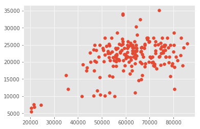

```python
debt = college[['2014.aid.median_debt.completers.overall']]
income = college[['2005.student.demographics.median_hh_income']]
plt.scatter(income, debt)
plt.show
```

[output not shown]

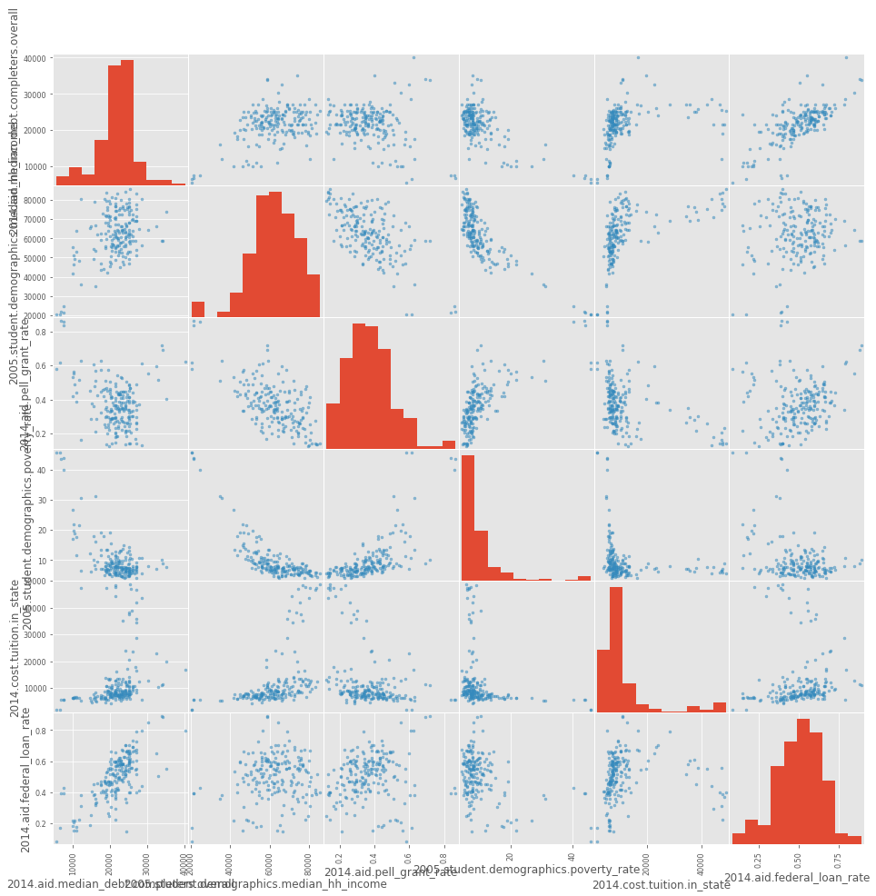

```python
scatter_matrix(college[['2014.aid.median_debt.completers.overall', '2005.student.demographics.median_hh_income', '2014.aid.pell_grant_rate', '2005.student.demographics.poverty_rate', '2014.cost.tuition.in_state', '2014.aid.federal_loan_rate']], figsize = (16,16))
```